# Estimate Robustness of Real Networks

```r
library(tidyverse)

# for parallel processing
library(foreach)
```

```
Error in library(foreach) : there is no package called ‘foreach’
```

Loop over web-of-life networks and calculate robustness.

```r
all_files <- dir("web-of-life_2020-01-15_120715/")

remove_these <- c(grep("README", all_files), grep("references", all_files))

all_webs <- all_files[-remove_these]
```

Pick the first one to test

```r
web <- read.csv(paste0("web-of-life_2020-01-15_120715/", all_webs[1]))

# rows are traits
N <- nrow(web)

# columns are species
S <- ncol(web)

c <- (N / sum(web)) * log(S)
```

Explore the sizes of the networks

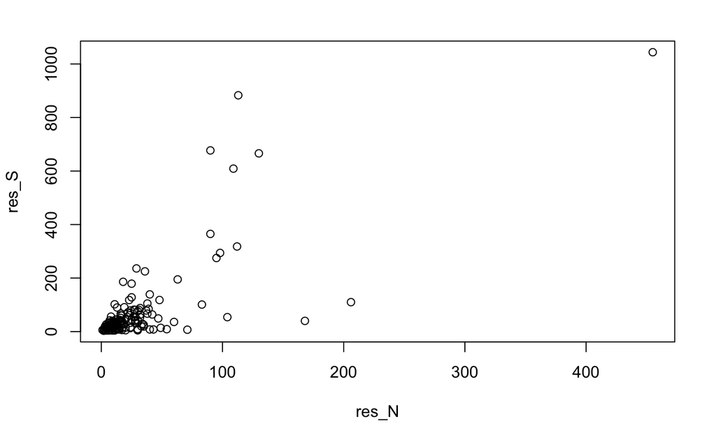

```r
res_S <- res_N <- test_traits <-
  var_traits <- mean_traits <- est_p <- dispersion_test <-
  numeric(length(all_webs))

for (i in 1:length(all_webs)) {

  # read in the web and convert to binary
  tmp <- sign(read.csv(paste0("web-of-life_2020-01-15_120715/", all_webs[i])))

  res_S[i] <- ncol(tmp)
  res_N[i] <- nrow(tmp)


  test_traits[i] <- min(rowSums(tmp))
  var_traits[i] <- var(rowSums(tmp))
  mean_traits[i] <- mean(rowSums(tmp))
  est_p[i] <- sum(tmp) / (res_S[i] * res_N[i])
  dispersion_test[i] <- (var_traits[i] / mean_traits[i]) * (1/(1-est_p[i]))

  # res_c[i] <- complexityEstimate(tmp)
  # res_r[i] <- sampleRobustness(tmp, nb = 100)

  # print(i)
}

plot(res_S ~ res_N)
```

```r
print(test_traits)
```

```
  [1]  1  1  1  1  1  1  1  2  1  3  1  1  1  1  1  1  1  1  1  1  1  1  1  1  2  1  1  1  1  1  1  1  2  2  1  1  1  2  2  1  1  1  1  1  1  4  1  1  1  1  1  1
 [53]  1  1  1  1  1  1  2  1  1  1  1  1  1  1  1  1  1  1  1  1  1  2  2  1  1  1  1  1  1  1  1  1  2  2  1  1  2  1  3  1  2  1  1  2  1  3  2  1  1  1  1  1
[105]  1  1  1  3  1  1  1  1  2  4  1  1  2  1  2  1  2  3  1  2  1  1  1  1  1  1  2 17  1  1  1  1  1  1  1  1  1  2  1  1  1  1  1  1  3  1  1  1  1  1  1  2
[157]  3  2  1  1  1  3  8  6  2  1  1  1  1  1  1  1  1  1  1  1  1  1  1  5  1  1
```

```r
print(var_traits)
```

```
  [1]  14.0464296  11.7398374   2.1042017  77.6181818 145.8470325  39.9291667  27.6666667  14.8444444  51.4031621  51.0850575   2.5897436  25.0410053  22.0000000
 [14]  42.4060847 271.7906380  68.7900000  75.0416667  34.3613087  31.6815115  58.8070175 225.7134831   7.8842105  34.0281385   3.4333333  51.1742424   2.9513630
 [27]   9.4926471  46.9737179  16.8151596   3.4102564   4.1665125  54.4000000  27.8787879 111.5000000   6.2245763   0.7777778   6.1111111  20.4761905  15.0666667
 [40]   9.2169312  13.9954023   1.0909091  25.1025641 125.8336731  13.3291667  48.5523810 372.6143791 449.6847291 116.0285714  14.2307692 196.3076923   9.5164835
 [53]  34.2061856  70.6916828  39.1664107 100.1852684 530.5739570  58.5849462   7.6060606  22.0444444  35.6545455  35.8409091  17.5684211   5.6441532   9.4233333
 [66]   2.9669312   7.5947712  12.6838235   9.7692308   2.2692308   9.7333333  16.1666667  27.7888889  19.7435897  13.9625000  11.1833333   9.7017544   3.3455882
 [79]   3.4727273   8.3000000   9.9015152   7.0909091   3.3333333   1.5833333   3.5833333   0.7000000   0.9047619   9.3636364   1.8777778   8.6964286   9.2000000
 [92]   3.2000000   2.2500000   1.7000000   1.7666667   1.7666667   1.2000000   7.3000000  12.6190476   1.2678571   2.0000000   6.4444444   1.6555556   2.0555556
[105]   2.0277778   9.6111111   5.5555556   0.9166667   6.0000000   6.2000000  16.9523810   5.2380952   3.3666667   6.9166667   4.7000000          NA   4.5000000
[118]   1.3571429   1.0666667   4.0111111   4.9444444   3.0666667   8.7857143   1.3333333   2.7000000   1.6964286   1.7500000   3.8777778   2.2727273  15.9821429
[131]   1.1428571  56.5797357   1.9776380   0.7435897   0.9473684   0.9195402   1.3379310   2.2482759   0.5073529   0.2777778   1.6000000   6.1428571   0.7596899
[144]  14.6173542  23.9102823  32.2342342  46.0000000  67.6291667  10.2666667   6.3402299   5.7971014   5.4791667   1.9981884   2.2000000   0.9682093   4.3809524
[157]   1.1000000   8.4217687   2.2777778   9.0588235  11.4991597  10.9238095  24.9166667  62.4743083   1.9523810   3.1362434  15.6424294  24.8677536  24.0955882
[170]  34.6454416   2.5274725   1.9636364   1.7666667   0.5000000   1.4727273   2.0000000   1.3333333   2.2500000   0.8589744   4.3333333   4.5151515  59.1895161
```

## Define some functions

```r
complexityEstimate <- function(A) {

  # rows are traits
  N <- nrow(A)

  # columns are species
  S <- ncol(A)

  c <- (N / sum(A)) * log(S)


}
```

```r
sampleRobustness <- function(A, nb = 1000){

  # number of Species
  S <- ncol(A)

  # vector of results
  res <- numeric(nb)

  # loop over replicates
  for (k in 1:nb) {

    species <- sample(S)

    # premute within rows
    Aperm <- A[,species]

    rob <- robustness(Aperm)

    res[k] <- rob

  }


return(mean(res))

}
```

```r
robustness <- function(Aperm){

   # number of Species
  S <- ncol(Aperm)

  # number of traits
  N <- nrow(Aperm)

  nn <- 0
  mm <- 0

  while (mm==0 & nn <= S) {
    nn <- nn + 1
    # mm <- min(rowSums( matrix(Aperm[, 1:nn], nrow = N, ncol = nn) ))
    mm <- min(rowSums( as.matrix(Aperm[, 1:nn])))
  }

  return( (S-nn+1) / (S * 1.0))
}
```

#for each trait compute the number of species, amongst the last n ones, that have that trait, take the min over all traits. If this min is 0, that means that the trait already gone. Thus we increment to check if that is true for n+1 remaining species. When this is no longer the case, we can affirm that exactly S + 1 - n extinctions led to the loss of one trait. repeat nb times.

[output not shown]

```r
save(ls(), file = "first_run.rda", compress = "xz")
```

```
Error in save(ls(), file = "first_run.rda", compress = "xz") :
  object ‘ls()’ not found
```

Convert to data.frame for processing

```r
df <- data.frame(complexity = res_c,
                 robustness = res_r,
                 n_species = res_S,
                 n_traits = res_N,
                 var_traits = var_traits,
                 mean_traits = mean_traits,
                 est_p = est_p,
                 dispersion_test = dispersion_test,
                 residual = res_r - ( 0.7*exp(-3.5*res_c**2)+.3*exp(-0.8*res_c))
                 )

new_c <- seq(0, 2.5, length = 100)
est_r <- 0.7*exp(-3.5*new_c**2)+.3*exp(-0.8*new_c)

fit_df <- data.frame(new_c = new_c,
                     est_r = est_r)
```

## Plot results

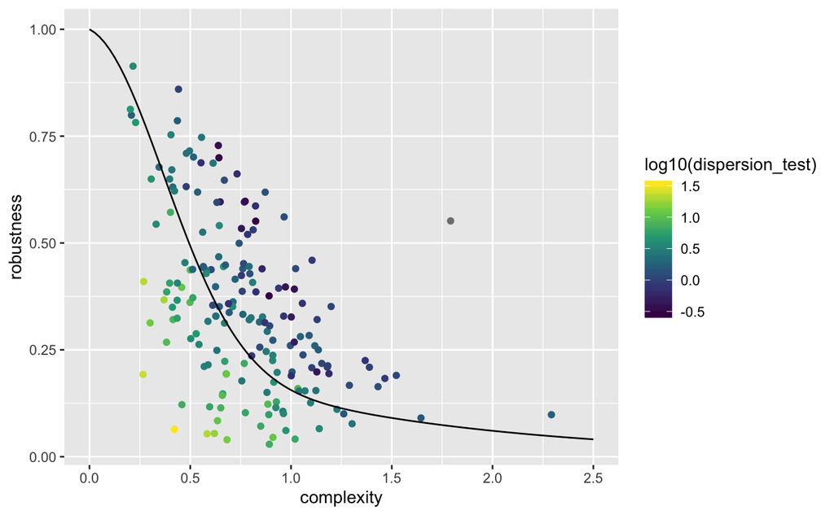

```r
g1 <- ggplot(df, aes(x = complexity,
                     y = robustness,
                     color = log10(dispersion_test))) +
  geom_point() +
  scale_color_viridis_c() +
  geom_line(data = fit_df, mapping = aes(x = new_c, y = est_r, color = NULL))

print(g1)
```

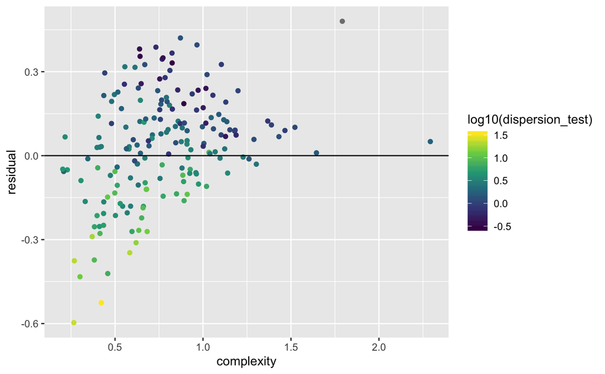

```r
g2 <- ggplot(df, aes(x = complexity,
                     y = residual,
                     color = log10(dispersion_test))) +
  geom_point() +
  scale_color_viridis_c() +
  geom_hline(yintercept = 0)
print(g2)
```

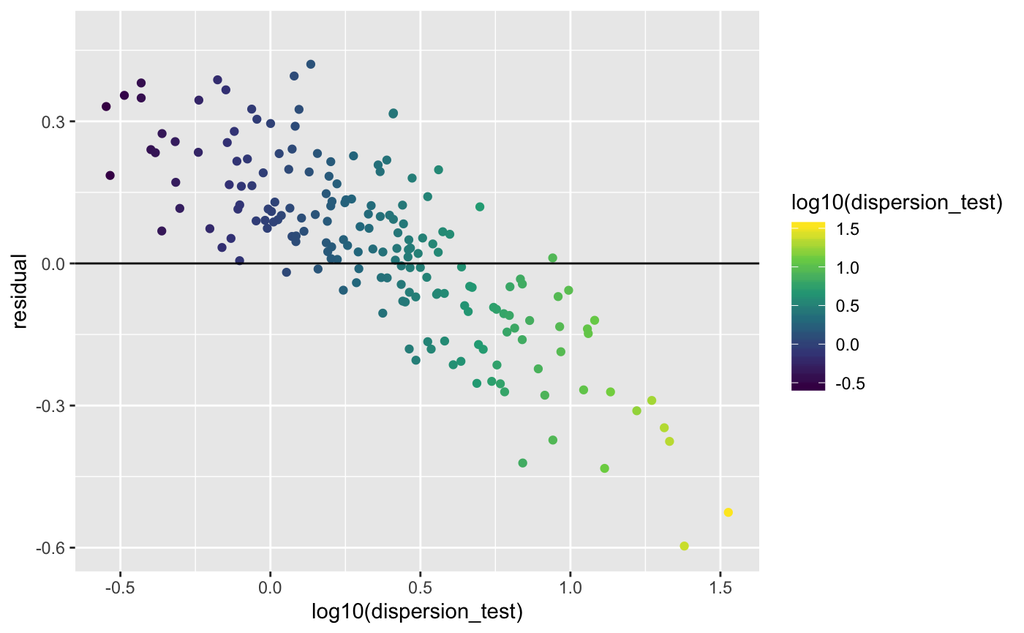

```r
g3 <- ggplot(df, aes(x = log10(dispersion_test),
                     y = residual,
                     color = log10(dispersion_test))) +
  geom_point() +
  scale_color_viridis_c() +
  geom_hline(yintercept = 0)
print(g3)
```

## Test on Jeff’s original seed dispersal network

```r
testA <- read.table("web-of-life_2020-01-15_120715/interactions.txt", header = TRUE)

#coerce to matrix and binary
testA <- sign(as.matrix(testA))

r <- sampleRobustness(testA, nb = 100)
c <- complexityEstimate(testA)
```